# Risk Factor Analysis

## Outcome Variable

**Outcome Variable:** ever_sstunted

## Predictor Variables

**Intervention Variable:** single

**Adjustment Set:**

- arm
- W_mage
- meducyrs
- feducyrs
- W_mhtcm
- W_mwtkg
- W_mbmi
- delta_W_mage
- delta_meducyrs
- delta_feducyrs
- delta_W_mhtcm
- delta_W_mwtkg
- delta_W_mbmi

## Stratifying Variables

The analysis was stratified on these variable(s):

- agecat
- studyid
- country

## Data Summary

| agecat | studyid | country | single | ever_sstunted | n_cell | n |
| --- | --- | --- | --- | --- | --- | --- |
| 0-24 months | COHORTS | GUATEMALA | 0 | 0 | 582 | 1207 |
| 0-24 months | COHORTS | GUATEMALA | 0 | 1 | 527 | 1207 |
| 0-24 months | COHORTS | GUATEMALA | 1 | 0 | 43 | 1207 |
| 0-24 months | COHORTS | GUATEMALA | 1 | 1 | 55 | 1207 |
| 0-24 months | COHORTS | INDIA | 0 | 0 | 4639 | 5384 |
| 0-24 months | COHORTS | INDIA | 0 | 1 | 736 | 5384 |
| 0-24 months | COHORTS | INDIA | 1 | 0 | 7 | 5384 |
| 0-24 months | COHORTS | INDIA | 1 | 1 | 2 | 5384 |
| 0-24 months | COHORTS | PHILIPPINES | 0 | 0 | 1889 | 3018 |
| 0-24 months | COHORTS | PHILIPPINES | 0 | 1 | 1054 | 3018 |
| 0-24 months | COHORTS | PHILIPPINES | 1 | 0 | 50 | 3018 |
| 0-24 months | COHORTS | PHILIPPINES | 1 | 1 | 25 | 3018 |
| 0-24 months | Guatemala BSC | GUATEMALA | 0 | 0 | 207 | 282 |
| 0-24 months | Guatemala BSC | GUATEMALA | 0 | 1 | 45 | 282 |
| 0-24 months | Guatemala BSC | GUATEMALA | 1 | 0 | 22 | 282 |
| 0-24 months | Guatemala BSC | GUATEMALA | 1 | 1 | 8 | 282 |
| 0-24 months | JiVitA-4 | BANGLADESH | 0 | 0 | 4312 | 5423 |
| 0-24 months | JiVitA-4 | BANGLADESH | 0 | 1 | 1103 | 5423 |
| 0-24 months | JiVitA-4 | BANGLADESH | 1 | 0 | 8 | 5423 |
| 0-24 months | JiVitA-4 | BANGLADESH | 1 | 1 | 0 | 5423 |
| 0-24 months | MAL-ED | BANGLADESH | 0 | 0 | 207 | 265 |
| 0-24 months | MAL-ED | BANGLADESH | 0 | 1 | 58 | 265 |
| 0-24 months | MAL-ED | BANGLADESH | 1 | 0 | 0 | 265 |
| 0-24 months | MAL-ED | BANGLADESH | 1 | 1 | 0 | 265 |
| 0-24 months | MAL-ED | BRAZIL | 0 | 0 | 183 | 233 |
| 0-24 months | MAL-ED | BRAZIL | 0 | 1 | 14 | 233 |
| 0-24 months | MAL-ED | BRAZIL | 1 | 0 | 28 | 233 |
| 0-24 months | MAL-ED | BRAZIL | 1 | 1 | 8 | 233 |
| 0-24 months | MAL-ED | INDIA | 0 | 0 | 192 | 249 |
| 0-24 months | MAL-ED | INDIA | 0 | 1 | 57 | 249 |

[output cut: 90 more lines]

The following strata were considered:

- agecat: 0-24 months, studyid: COHORTS, country: GUATEMALA
- agecat: 0-24 months, studyid: COHORTS, country: INDIA
- agecat: 0-24 months, studyid: COHORTS, country: PHILIPPINES
- agecat: 0-24 months, studyid: Guatemala BSC, country: GUATEMALA
- agecat: 0-24 months, studyid: JiVitA-4, country: BANGLADESH
- agecat: 0-24 months, studyid: MAL-ED, country: BANGLADESH
- agecat: 0-24 months, studyid: MAL-ED, country: BRAZIL
- agecat: 0-24 months, studyid: MAL-ED, country: INDIA
- agecat: 0-24 months, studyid: MAL-ED, country: NEPAL
- agecat: 0-24 months, studyid: MAL-ED, country: PERU
- agecat: 0-24 months, studyid: MAL-ED, country: SOUTH AFRICA
- agecat: 0-24 months, studyid: MAL-ED, country: TANZANIA, UNITED REPUBLIC OF
- agecat: 0-24 months, studyid: PROBIT, country: BELARUS
- agecat: 0-24 months, studyid: TanzaniaChild2, country: TANZANIA, UNITED REPUBLIC OF
- agecat: 0-24 months, studyid: ZVITAMBO, country: ZIMBABWE
- agecat: 0-6 months, studyid: COHORTS, country: GUATEMALA
- agecat: 0-6 months, studyid: COHORTS, country: INDIA
- agecat: 0-6 months, studyid: COHORTS, country: PHILIPPINES
- agecat: 0-6 months, studyid: Guatemala BSC, country: GUATEMALA
- agecat: 0-6 months, studyid: JiVitA-4, country: BANGLADESH
- agecat: 0-6 months, studyid: MAL-ED, country: BANGLADESH
- agecat: 0-6 months, studyid: MAL-ED, country: BRAZIL
- agecat: 0-6 months, studyid: MAL-ED, country: INDIA
- agecat: 0-6 months, studyid: MAL-ED, country: NEPAL
- agecat: 0-6 months, studyid: MAL-ED, country: PERU
- agecat: 0-6 months, studyid: MAL-ED, country: SOUTH AFRICA
- agecat: 0-6 months, studyid: MAL-ED, country: TANZANIA, UNITED REPUBLIC OF
- agecat: 0-6 months, studyid: PROBIT, country: BELARUS
- agecat: 0-6 months, studyid: TanzaniaChild2, country: TANZANIA, UNITED REPUBLIC OF
- agecat: 0-6 months, studyid: ZVITAMBO, country: ZIMBABWE

### Dropped Strata

Some strata were dropped due to rare outcomes:

- agecat: 0-24 months, studyid: COHORTS, country: INDIA
- agecat: 0-24 months, studyid: JiVitA-4, country: BANGLADESH
- agecat: 0-24 months, studyid: MAL-ED, country: BANGLADESH
- agecat: 0-24 months, studyid: MAL-ED, country: INDIA
- agecat: 0-24 months, studyid: MAL-ED, country: NEPAL
- agecat: 0-24 months, studyid: MAL-ED, country: TANZANIA, UNITED REPUBLIC OF
- agecat: 0-6 months, studyid: COHORTS, country: INDIA
- agecat: 0-6 months, studyid: JiVitA-4, country: BANGLADESH
- agecat: 0-6 months, studyid: MAL-ED, country: BANGLADESH
- agecat: 0-6 months, studyid: MAL-ED, country: INDIA
- agecat: 0-6 months, studyid: MAL-ED, country: NEPAL
- agecat: 0-6 months, studyid: MAL-ED, country: TANZANIA, UNITED REPUBLIC OF

## Methods Detail

We’re interested in the causal parameters $E[Y_a]$ for all values of $a \in \mathcal{A}$. These parameters represent the mean outcome if, possibly contrary to fact, we intervened to set all units to have $A=a$. Under the randomization and positivity assumptions, these are identified by the statistical parameters $\psi_a=E_W[E_{Y|A,W}(Y|A=a,W)]$. In addition, we’re interested in the mean of $Y$, $E[Y]$ under no intervention (the observed mean). We will estimate these parameters by using SuperLearner to fit the relevant likelihood factors – $E_{Y|A,W}(Y|A=a,W)$ and $p(A=a|W)$, and then updating our likelihood fit using a joint TMLE.

For unadjusted analyses ($W=\{\}$), initial likelihoods were estimated using Lrnr_glm to estimate the simple $E(Y|A)$ and Lrnr_mean to estimate $p(A)$. For adjusted analyses, a small library containing Lrnr_glmnet, Lrnr_xgboost, and Lrnr_mean was used.

Having estimated these parameters, we will then use the delta method to estimate relative risks and attributable risks relative to a prespecified baseline level of $A$.

# Results Detail

## Results Plots

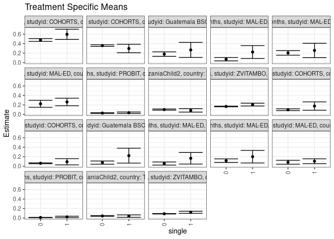

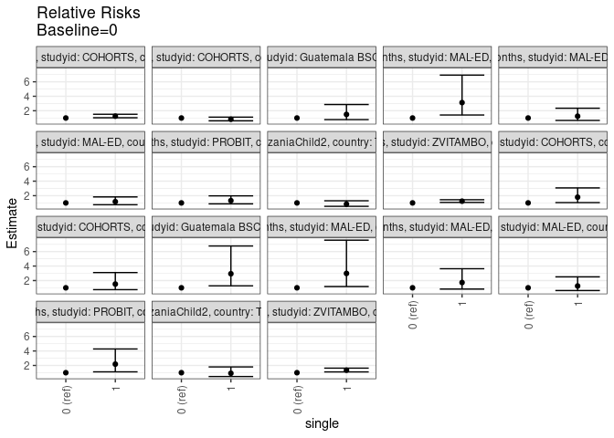

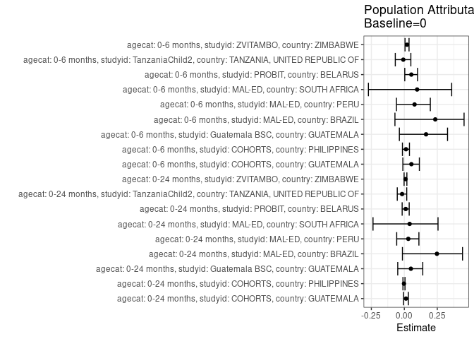

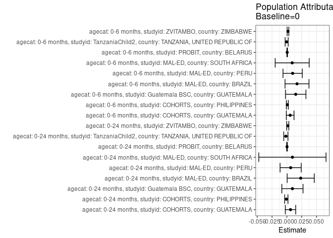

## Results Table

### Parameter: TSM

| agecat | studyid | country | intervention_level | baseline_level | estimate | ci_lower | ci_upper |
| --- | --- | --- | --- | --- | --- | --- | --- |
| 0-24 months | COHORTS | GUATEMALA | 0 | NA | 0.4760867 | 0.4465504 | 0.5056230 |
| 0-24 months | COHORTS | GUATEMALA | 1 | NA | 0.5959051 | 0.4875297 | 0.7042806 |
| 0-24 months | COHORTS | PHILIPPINES | 0 | NA | 0.3584241 | 0.3409896 | 0.3758586 |
| 0-24 months | COHORTS | PHILIPPINES | 1 | NA | 0.2968146 | 0.2081099 | 0.3855192 |
| 0-24 months | Guatemala BSC | GUATEMALA | 0 | NA | 0.1785714 | 0.1312007 | 0.2259422 |
| 0-24 months | Guatemala BSC | GUATEMALA | 1 | NA | 0.2666667 | 0.1081431 | 0.4251903 |
| 0-24 months | MAL-ED | BRAZIL | 0 | NA | 0.0710660 | 0.0351099 | 0.1070221 |
| 0-24 months | MAL-ED | BRAZIL | 1 | NA | 0.2222222 | 0.0861240 | 0.3583204 |
| 0-24 months | MAL-ED | PERU | 0 | NA | 0.2048432 | 0.1566629 | 0.2530234 |
| 0-24 months | MAL-ED | PERU | 1 | NA | 0.2560861 | 0.1052089 | 0.4069634 |
| 0-24 months | MAL-ED | SOUTH AFRICA | 0 | NA | 0.2231133 | 0.1492934 | 0.2969332 |
| 0-24 months | MAL-ED | SOUTH AFRICA | 1 | NA | 0.2612497 | 0.1813697 | 0.3411298 |
| 0-24 months | PROBIT | BELARUS | 0 | NA | 0.0273419 | 0.0196298 | 0.0350539 |
| 0-24 months | PROBIT | BELARUS | 1 | NA | 0.0358677 | 0.0210562 | 0.0506791 |
| 0-24 months | TanzaniaChild2 | TANZANIA, UNITED REPUBLIC OF | 0 | NA | 0.1014746 | 0.0887165 | 0.1142327 |
| 0-24 months | TanzaniaChild2 | TANZANIA, UNITED REPUBLIC OF | 1 | NA | 0.0842197 | 0.0482398 | 0.1201996 |
| 0-24 months | ZVITAMBO | ZIMBABWE | 0 | NA | 0.1665214 | 0.1601193 | 0.1729236 |
| 0-24 months | ZVITAMBO | ZIMBABWE | 1 | NA | 0.2062188 | 0.1766374 | 0.2358001 |
| 0-6 months | COHORTS | GUATEMALA | 0 | NA | 0.0981379 | 0.0787226 | 0.1175531 |
| 0-6 months | COHORTS | GUATEMALA | 1 | NA | 0.1756071 | 0.0872173 | 0.2639969 |
| 0-6 months | COHORTS | PHILIPPINES | 0 | NA | 0.0615019 | 0.0528192 | 0.0701845 |
| 0-6 months | COHORTS | PHILIPPINES | 1 | NA | 0.0933333 | 0.0278797 | 0.1587870 |
| 0-6 months | Guatemala BSC | GUATEMALA | 0 | NA | 0.0756303 | 0.0419751 | 0.1092854 |
| 0-6 months | Guatemala BSC | GUATEMALA | 1 | NA | 0.2222222 | 0.0651105 | 0.3793340 |
| 0-6 months | MAL-ED | BRAZIL | 0 | NA | 0.0558376 | 0.0237057 | 0.0879694 |
| 0-6 months | MAL-ED | BRAZIL | 1 | NA | 0.1666667 | 0.0446653 | 0.2886680 |
| 0-6 months | MAL-ED | PERU | 0 | NA | 0.1156716 | 0.0773169 | 0.1540264 |
| 0-6 months | MAL-ED | PERU | 1 | NA | 0.2000000 | 0.0672630 | 0.3327370 |
| 0-6 months | MAL-ED | SOUTH AFRICA | 0 | NA | 0.0833763 | 0.0420674 | 0.1246851 |
| 0-6 months | MAL-ED | SOUTH AFRICA | 1 | NA | 0.1043045 | 0.0531579 | 0.1554511 |
| 0-6 months | PROBIT | BELARUS | 0 | NA | 0.0103689 | 0.0068989 | 0.0138389 |
| 0-6 months | PROBIT | BELARUS | 1 | NA | 0.0226495 | 0.0078810 | 0.0374180 |
| 0-6 months | TanzaniaChild2 | TANZANIA, UNITED REPUBLIC OF | 0 | NA | 0.0437006 | 0.0350597 | 0.0523415 |
| 0-6 months | TanzaniaChild2 | TANZANIA, UNITED REPUBLIC OF | 1 | NA | 0.0401786 | 0.0144564 | 0.0659008 |
| 0-6 months | ZVITAMBO | ZIMBABWE | 0 | NA | 0.0893321 | 0.0844482 | 0.0942159 |
| 0-6 months | ZVITAMBO | ZIMBABWE | 1 | NA | 0.1201006 | 0.0979730 | 0.1422282 |

### Parameter: E(Y)

| agecat | studyid | country | intervention_level | baseline_level | estimate | ci_lower | ci_upper |
| --- | --- | --- | --- | --- | --- | --- | --- |
| 0-24 months | COHORTS | GUATEMALA | NA | NA | 0.4821872 | 0.4539860 | 0.5103885 |
| 0-24 months | COHORTS | PHILIPPINES | NA | NA | 0.3575215 | 0.3404198 | 0.3746233 |
| 0-24 months | Guatemala BSC | GUATEMALA | NA | NA | 0.1879433 | 0.1422658 | 0.2336207 |
| 0-24 months | MAL-ED | BRAZIL | NA | NA | 0.0944206 | 0.0567935 | 0.1320477 |
| 0-24 months | MAL-ED | PERU | NA | NA | 0.2112211 | 0.1651858 | 0.2572564 |
| 0-24 months | MAL-ED | SOUTH AFRICA | NA | NA | 0.2324841 | 0.1856873 | 0.2792809 |
| 0-24 months | PROBIT | BELARUS | NA | NA | 0.0276380 | 0.0201988 | 0.0350773 |
| 0-24 months | TanzaniaChild2 | TANZANIA, UNITED REPUBLIC OF | NA | NA | 0.0997895 | 0.0877330 | 0.1118460 |
| 0-24 months | ZVITAMBO | ZIMBABWE | NA | NA | 0.1680223 | 0.1618323 | 0.1742123 |
| 0-6 months | COHORTS | GUATEMALA | NA | NA | 0.1036961 | 0.0845403 | 0.1228519 |
| 0-6 months | COHORTS | PHILIPPINES | NA | NA | 0.0622929 | 0.0536688 | 0.0709170 |
| 0-6 months | Guatemala BSC | GUATEMALA | NA | NA | 0.0905660 | 0.0559470 | 0.1251850 |
| 0-6 months | MAL-ED | BRAZIL | NA | NA | 0.0729614 | 0.0394957 | 0.1064270 |
| 0-6 months | MAL-ED | PERU | NA | NA | 0.1254125 | 0.0880603 | 0.1627648 |
| 0-6 months | MAL-ED | SOUTH AFRICA | NA | NA | 0.0923567 | 0.0602816 | 0.1244318 |
| 0-6 months | PROBIT | BELARUS | NA | NA | 0.0109519 | 0.0074064 | 0.0144975 |
| 0-6 months | TanzaniaChild2 | TANZANIA, UNITED REPUBLIC OF | NA | NA | 0.0433684 | 0.0351750 | 0.0515619 |
| 0-6 months | ZVITAMBO | ZIMBABWE | NA | NA | 0.0912208 | 0.0864511 | 0.0959905 |

### Parameter: RR

| agecat | studyid | country | intervention_level | baseline_level | estimate | ci_lower | ci_upper |
| --- | --- | --- | --- | --- | --- | --- | --- |
| 0-24 months | COHORTS | GUATEMALA | 0 | 0 | 1.0000000 | 1.0000000 | 1.000000 |
| 0-24 months | COHORTS | GUATEMALA | 1 | 0 | 1.2516735 | 1.0336325 | 1.515710 |
| 0-24 months | COHORTS | PHILIPPINES | 0 | 0 | 1.0000000 | 1.0000000 | 1.000000 |
| 0-24 months | COHORTS | PHILIPPINES | 1 | 0 | 0.8281099 | 0.6117918 | 1.120914 |
| 0-24 months | Guatemala BSC | GUATEMALA | 0 | 0 | 1.0000000 | 1.0000000 | 1.000000 |
| 0-24 months | Guatemala BSC | GUATEMALA | 1 | 0 | 1.4933333 | 0.7788347 | 2.863309 |
| 0-24 months | MAL-ED | BRAZIL | 0 | 0 | 1.0000000 | 1.0000000 | 1.000000 |
| 0-24 months | MAL-ED | BRAZIL | 1 | 0 | 3.1269841 | 1.4129327 | 6.920379 |
| 0-24 months | MAL-ED | PERU | 0 | 0 | 1.0000000 | 1.0000000 | 1.000000 |
| 0-24 months | MAL-ED | PERU | 1 | 0 | 1.2501571 | 0.6651479 | 2.349692 |
| 0-24 months | MAL-ED | SOUTH AFRICA | 0 | 0 | 1.0000000 | 1.0000000 | 1.000000 |
| 0-24 months | MAL-ED | SOUTH AFRICA | 1 | 0 | 1.1709287 | 0.7499564 | 1.828205 |
| 0-24 months | PROBIT | BELARUS | 0 | 0 | 1.0000000 | 1.0000000 | 1.000000 |
| 0-24 months | PROBIT | BELARUS | 1 | 0 | 1.3118227 | 0.8707461 | 1.976327 |
| 0-24 months | TanzaniaChild2 | TANZANIA, UNITED REPUBLIC OF | 0 | 0 | 1.0000000 | 1.0000000 | 1.000000 |
| 0-24 months | TanzaniaChild2 | TANZANIA, UNITED REPUBLIC OF | 1 | 0 | 0.8299585 | 0.5321405 | 1.294453 |
| 0-24 months | ZVITAMBO | ZIMBABWE | 0 | 0 | 1.0000000 | 1.0000000 | 1.000000 |
| 0-24 months | ZVITAMBO | ZIMBABWE | 1 | 0 | 1.2383916 | 1.0677578 | 1.436294 |
| 0-6 months | COHORTS | GUATEMALA | 0 | 0 | 1.0000000 | 1.0000000 | 1.000000 |
| 0-6 months | COHORTS | GUATEMALA | 1 | 0 | 1.7893921 | 1.0432502 | 3.069181 |
| 0-6 months | COHORTS | PHILIPPINES | 0 | 0 | 1.0000000 | 1.0000000 | 1.000000 |
| 0-6 months | COHORTS | PHILIPPINES | 1 | 0 | 1.5175691 | 0.7421172 | 3.103305 |
| 0-6 months | Guatemala BSC | GUATEMALA | 0 | 0 | 1.0000000 | 1.0000000 | 1.000000 |
| 0-6 months | Guatemala BSC | GUATEMALA | 1 | 0 | 2.9382716 | 1.2743457 | 6.774802 |
| 0-6 months | MAL-ED | BRAZIL | 0 | 0 | 1.0000000 | 1.0000000 | 1.000000 |
| 0-6 months | MAL-ED | BRAZIL | 1 | 0 | 2.9848485 | 1.1763672 | 7.573588 |
| 0-6 months | MAL-ED | PERU | 0 | 0 | 1.0000000 | 1.0000000 | 1.000000 |
| 0-6 months | MAL-ED | PERU | 1 | 0 | 1.7290323 | 0.8233744 | 3.630854 |
| 0-6 months | MAL-ED | SOUTH AFRICA | 0 | 0 | 1.0000000 | 1.0000000 | 1.000000 |
| 0-6 months | MAL-ED | SOUTH AFRICA | 1 | 0 | 1.2510091 | 0.6233033 | 2.510855 |
| 0-6 months | PROBIT | BELARUS | 0 | 0 | 1.0000000 | 1.0000000 | 1.000000 |
| 0-6 months | PROBIT | BELARUS | 1 | 0 | 2.1843688 | 1.1166135 | 4.273159 |
| 0-6 months | TanzaniaChild2 | TANZANIA, UNITED REPUBLIC OF | 0 | 0 | 1.0000000 | 1.0000000 | 1.000000 |
| 0-6 months | TanzaniaChild2 | TANZANIA, UNITED REPUBLIC OF | 1 | 0 | 0.9194054 | 0.4704504 | 1.796802 |
| 0-6 months | ZVITAMBO | ZIMBABWE | 0 | 0 | 1.0000000 | 1.0000000 | 1.000000 |
| 0-6 months | ZVITAMBO | ZIMBABWE | 1 | 0 | 1.3444290 | 1.1095391 | 1.629045 |

### Parameter: PAR

| agecat | studyid | country | intervention_level | baseline_level | estimate | ci_lower | ci_upper |
| --- | --- | --- | --- | --- | --- | --- | --- |
| 0-24 months | COHORTS | GUATEMALA | 0 | NA | 0.0061005 | -0.0026898 | 0.0148908 |
| 0-24 months | COHORTS | PHILIPPINES | 0 | NA | -0.0009026 | -0.0037017 | 0.0018965 |
| 0-24 months | Guatemala BSC | GUATEMALA | 0 | NA | 0.0093718 | -0.0085135 | 0.0272571 |
| 0-24 months | MAL-ED | BRAZIL | 0 | NA | 0.0233546 | 0.0004972 | 0.0462121 |
| 0-24 months | MAL-ED | PERU | 0 | NA | 0.0063780 | -0.0114205 | 0.0241764 |
| 0-24 months | MAL-ED | SOUTH AFRICA | 0 | NA | 0.0093708 | -0.0472790 | 0.0660206 |
| 0-24 months | PROBIT | BELARUS | 0 | NA | 0.0002962 | -0.0004101 | 0.0010025 |
| 0-24 months | TanzaniaChild2 | TANZANIA, UNITED REPUBLIC OF | 0 | NA | -0.0016852 | -0.0052743 | 0.0019040 |
| 0-24 months | ZVITAMBO | ZIMBABWE | 0 | NA | 0.0015008 | -0.0002774 | 0.0032790 |
| 0-6 months | COHORTS | GUATEMALA | 0 | NA | 0.0055582 | -0.0009822 | 0.0120987 |
| 0-6 months | COHORTS | PHILIPPINES | 0 | NA | 0.0007910 | -0.0008691 | 0.0024512 |
| 0-6 months | Guatemala BSC | GUATEMALA | 0 | NA | 0.0149358 | -0.0022867 | 0.0321583 |
| 0-6 months | MAL-ED | BRAZIL | 0 | NA | 0.0171238 | -0.0030390 | 0.0372866 |
| 0-6 months | MAL-ED | PERU | 0 | NA | 0.0097409 | -0.0065060 | 0.0259878 |
| 0-6 months | MAL-ED | SOUTH AFRICA | 0 | NA | 0.0089804 | -0.0196983 | 0.0376591 |
| 0-6 months | PROBIT | BELARUS | 0 | NA | 0.0005830 | 0.0000449 | 0.0011211 |
| 0-6 months | TanzaniaChild2 | TANZANIA, UNITED REPUBLIC OF | 0 | NA | -0.0003322 | -0.0028918 | 0.0022274 |
| 0-6 months | ZVITAMBO | ZIMBABWE | 0 | NA | 0.0018887 | 0.0004964 | 0.0032811 |

### Parameter: PAF

| agecat | studyid | country | intervention_level | baseline_level | estimate | ci_lower | ci_upper |
| --- | --- | --- | --- | --- | --- | --- | --- |
| 0-24 months | COHORTS | GUATEMALA | 0 | NA | 0.0126518 | -0.0057626 | 0.0307290 |
| 0-24 months | COHORTS | PHILIPPINES | 0 | NA | -0.0025245 | -0.0103806 | 0.0052705 |
| 0-24 months | Guatemala BSC | GUATEMALA | 0 | NA | 0.0498652 | -0.0497480 | 0.1400259 |
| 0-24 months | MAL-ED | BRAZIL | 0 | NA | 0.2473466 | -0.0142644 | 0.4414798 |
| 0-24 months | MAL-ED | PERU | 0 | NA | 0.0301957 | -0.0576158 | 0.1107163 |
| 0-24 months | MAL-ED | SOUTH AFRICA | 0 | NA | 0.0403072 | -0.2373656 | 0.2556685 |
| 0-24 months | PROBIT | BELARUS | 0 | NA | 0.0107161 | -0.0163382 | 0.0370502 |
| 0-24 months | TanzaniaChild2 | TANZANIA, UNITED REPUBLIC OF | 0 | NA | -0.0168871 | -0.0534471 | 0.0184040 |
| 0-24 months | ZVITAMBO | ZIMBABWE | 0 | NA | 0.0089323 | -0.0017054 | 0.0194571 |
| 0-6 months | COHORTS | GUATEMALA | 0 | NA | 0.0536013 | -0.0110660 | 0.1141325 |
| 0-6 months | COHORTS | PHILIPPINES | 0 | NA | 0.0126987 | -0.0142640 | 0.0389447 |
| 0-6 months | Guatemala BSC | GUATEMALA | 0 | NA | 0.1649160 | -0.0375013 | 0.3278415 |
| 0-6 months | MAL-ED | BRAZIL | 0 | NA | 0.2346969 | -0.0710660 | 0.4531721 |
| 0-6 months | MAL-ED | PERU | 0 | NA | 0.0776709 | -0.0596587 | 0.1972028 |
| 0-6 months | MAL-ED | SOUTH AFRICA | 0 | NA | 0.0972361 | -0.2722160 | 0.3593991 |
| 0-6 months | PROBIT | BELARUS | 0 | NA | 0.0532353 | 0.0035276 | 0.1004634 |
| 0-6 months | TanzaniaChild2 | TANZANIA, UNITED REPUBLIC OF | 0 | NA | -0.0076596 | -0.0684244 | 0.0496494 |
| 0-6 months | ZVITAMBO | ZIMBABWE | 0 | NA | 0.0207052 | 0.0053520 | 0.0358214 |